# Stock portfolio summary

BScheliga

31 May, 2022

## Abstract

This is script allow you to assess the performance, dividend yield and the sector and market distribution of your stock portfolio. It retrieves the historical stock records based in the EPIC from https://www.alphavantage.co/. The usage of Alpha Vantage requires an API-key, which can be requested here https://www.alphavantage.co/support/#api-key

### Note:

- change wd to more appropiate
- Add geography category (e.g. Continents or countries maybe)

### Known (potential) issues:

- freshly bought stocks won’t show up in the summary until a daily value is available
- for app with data entry tool. the user need to investigate, if stock it traded in GPX or GBP
- Initial I used Yahoo.finance as a data source, but their data was of poor quality. e.g. inconsistent in stock value unit, a timeseries could have GPX and GPB. Hence, I changed to Alpha Vatage. However, they require you to have an API.KEY.
- identical EPIC’s at different Stock exchange, will cause a problems in some of the loops where *vec_EPIC* is used
- when calculating the investments selling stock with a lose will generate positive values in the cs_???_Inv columns. However, that money is actually lost :(
- not sure how the plots respond to Stock being completetly sold and later repurchased.

# Sells (*Find better title later* and move this calucaltion update)

| EPIC | Bought [£] | Sold [£] | Gain & Losses [£] | Gain & Losses [%] | Gain & Losses corrected* [£] | Time held |
| --- | --- | --- | --- | --- | --- | --- |
| VUSA | 998.05 | 1240.05 | 242 | 19.5 | 236.39 | 248 days |

**includes trading costs and dividend payouts that occurred while the stock was held*

# Portfolio distribution

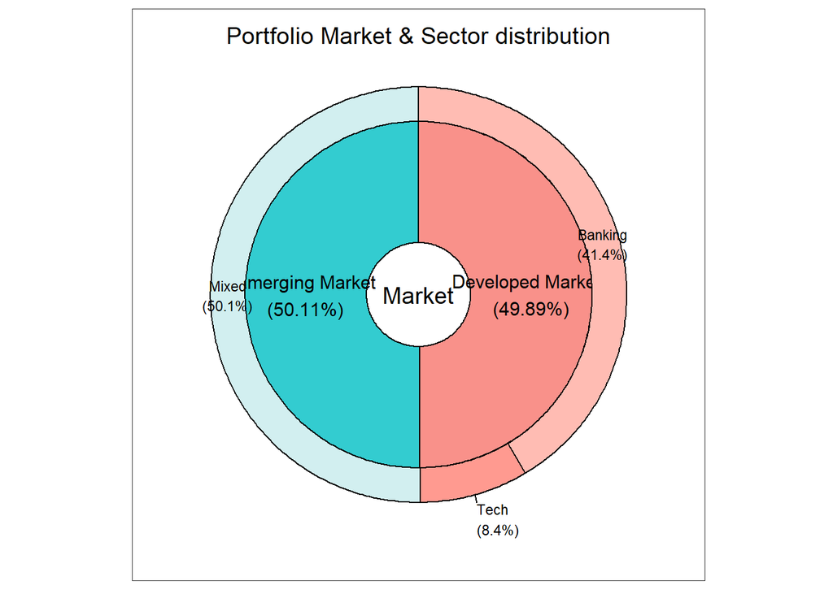

Figure 1. A Pie chart showing the portfolio’s distribution in the different markets (inner ring) and sectors (outer ring). The *“Mixed”* are EFT’s that do not focus on a specific sector (e.g. MSCI world).

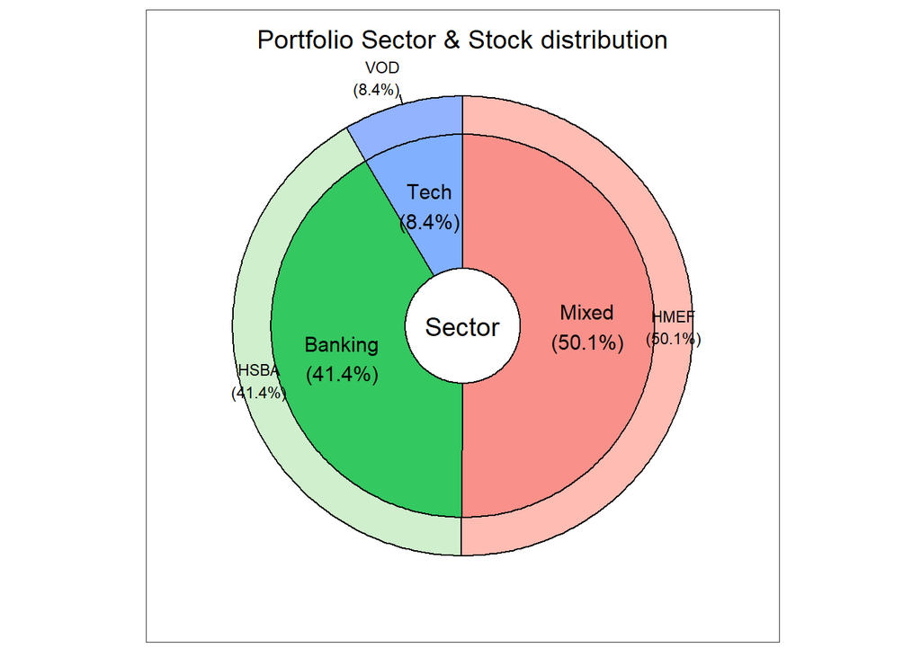

Figure 2. A Pie chart showing the portfolio’s distribution in the different sectors (inner ring) and the respective stocks in the portfolio (outer ring). The *“Mixed”* are EFT’s that do not focus on a specific sector (e.g. MSCI world).

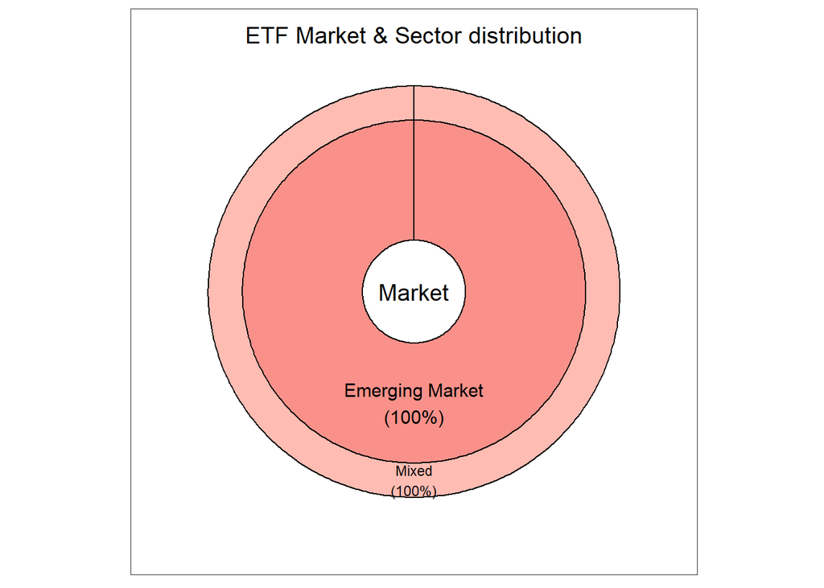

Figure 3. A Pie chart showing the portfolio’s EFT distribution in the different markets (inner ring) and the respective sector distribution (outer ring). The *“Mixed”* are EFT’s that do not focus on a specific sector (e.g. MSCI world).

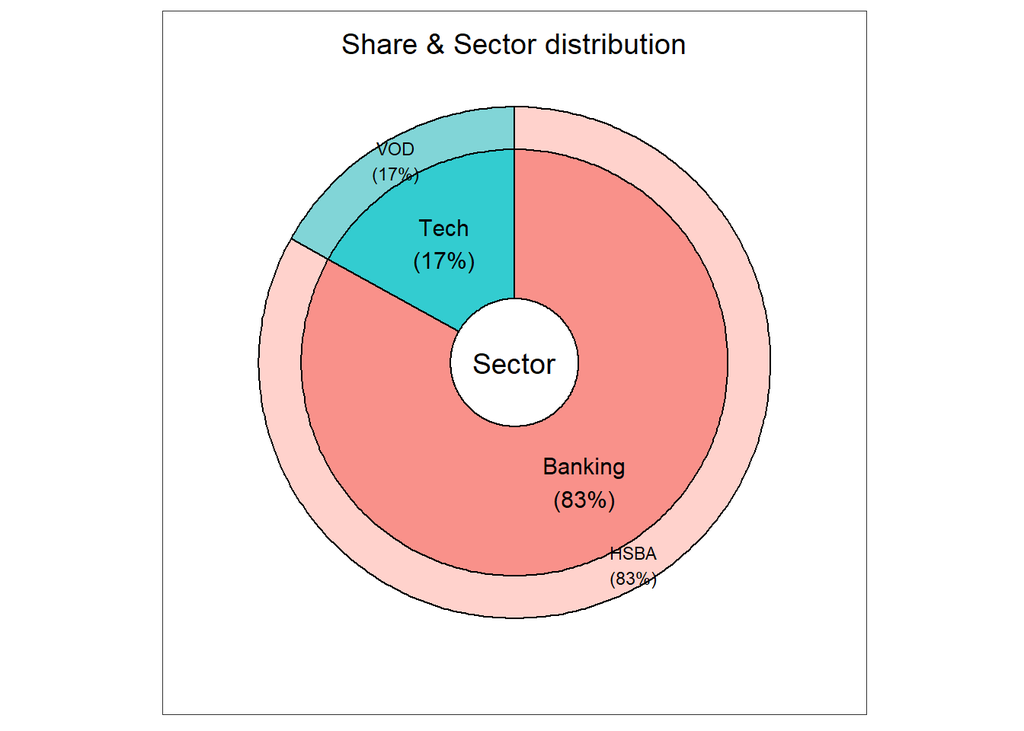

Figure 4. A Pie chart showing the portfolio’s share distribution in the different sectors (inner ring) and the respective stocks (outer ring).

# Portfolio performance

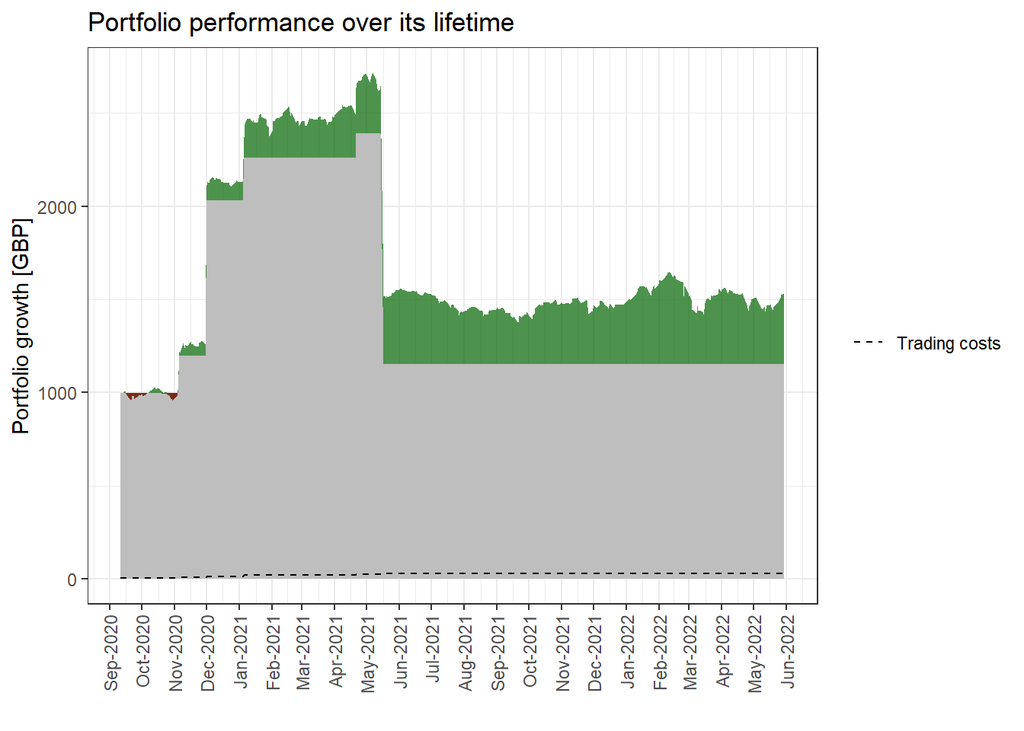

Figure 5. Shows the Portfolio performance over its lifetime with the growth (green) and the shrinking (red) of the investment (grey). The trading costs are represented by the black dashed line.

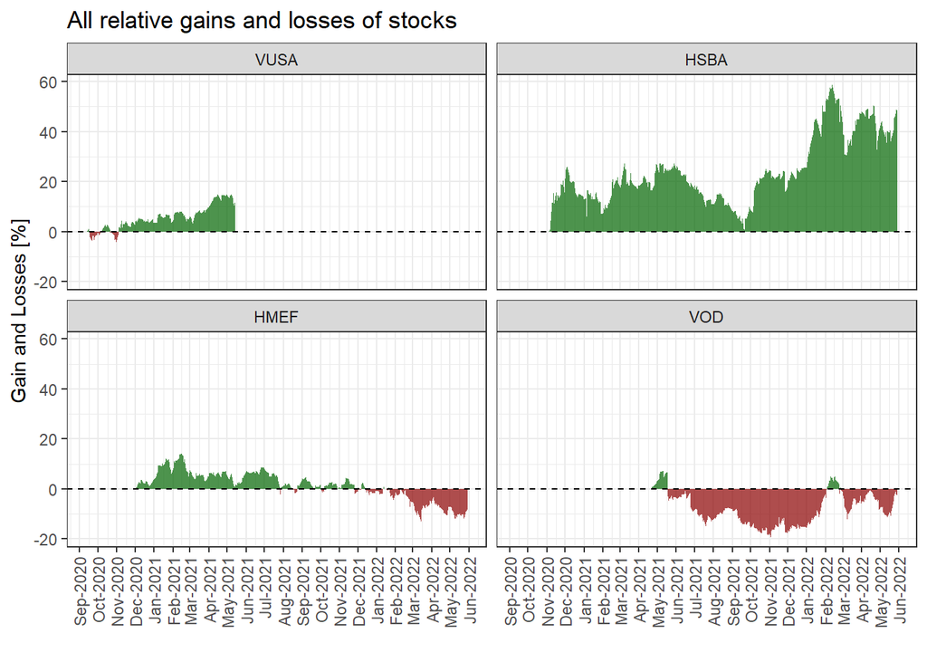

Figure 6. Shows the all relative gains (green) and losses (red) of the stocks inside the portfolio based on their the daily closing values. The shown time period is based on the buy and sold actions surrounding the respective stock. If a stock is completely sold, it time series stop. The relative gains and losses are based on the overall investment into the respective stock.

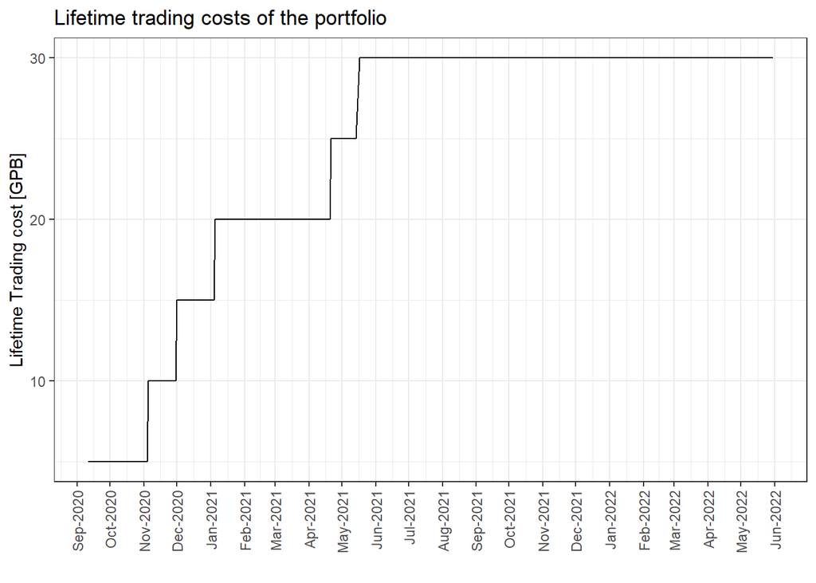

Figure 7. Shows the trading costs over the lifetime of the portfolio.

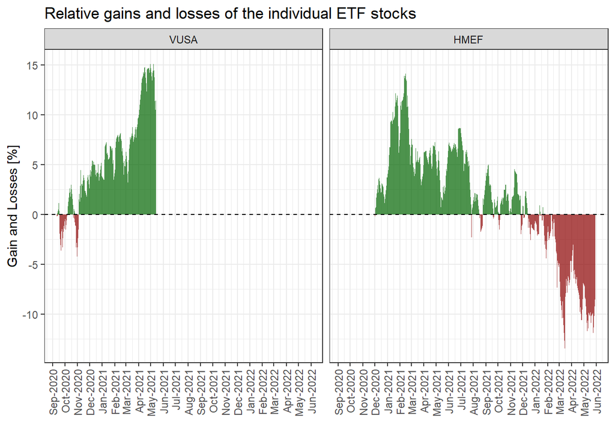

Figure 8. Shows the relative gains (green) and losses (red) of the ETF stocks inside the portfolio based on their the daily closing values. The shown time period is based on the buy and sold actions surrounding the respective stock. If a stock is completely sold, it time series stop. The relative gains and losses are based on the overall investment into the respective stock.

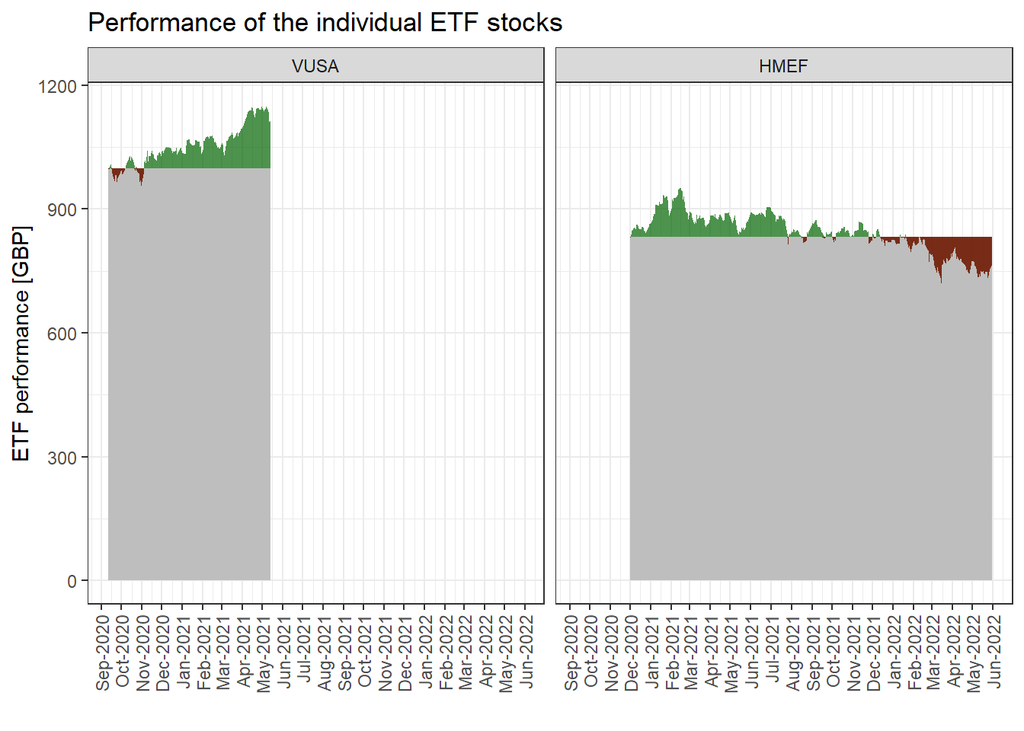

Figure 9. Shows the individual ETF stock performance over their lifetime in the portfolio with the growth (green) and the shrinking (red) of the investment (grey).

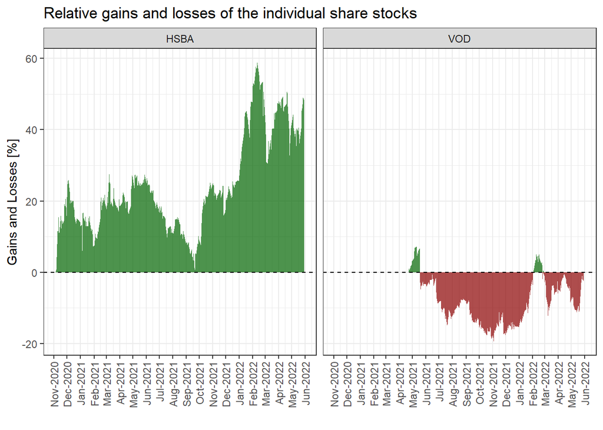

Figure 10. Shows the relative gains (green) and losses (red) of the share stocks inside the portfolio based on their the daily closing values. The shown time period is based on the buy and sold actions surrounding the respective stock. If a stock is completely sold, it time series stop. The relative gains and losses are based on the overall investment into the respective stock.

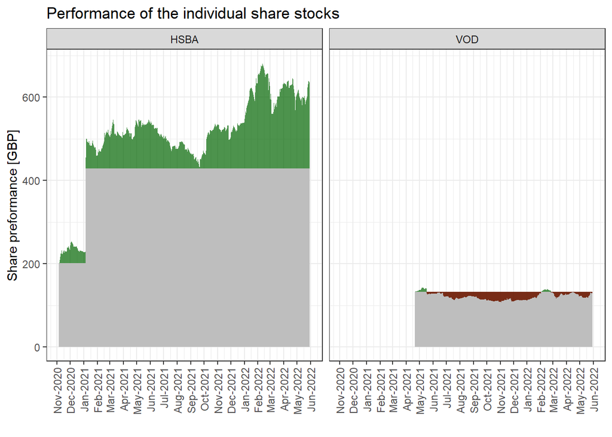

Figure 11. Shows the Individual share stock performance over their lifetime in the portfolio with the growth (green) and the shrinking (red) of the investment (grey).

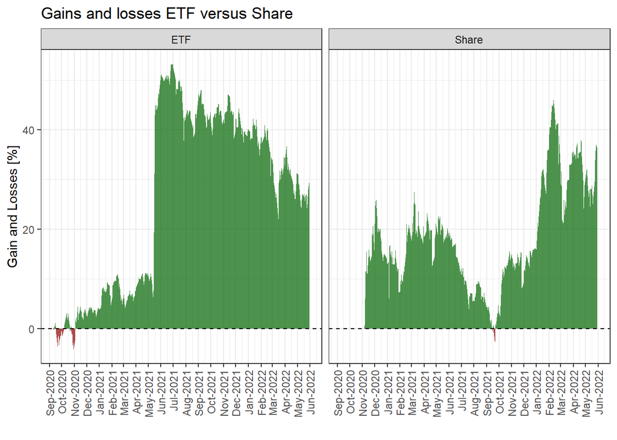

Figure 12. Shows the relative gains (green) and losses (red) between ETF and share stocks in the portfolio based on their the daily closing values. The shown time period is based on the buy and sold actions surrounding the respective stock. If a stock is completely sold, it time series stop. The relative gains and losses are based on the overall investment into the respective stock.

# Dividend assessment

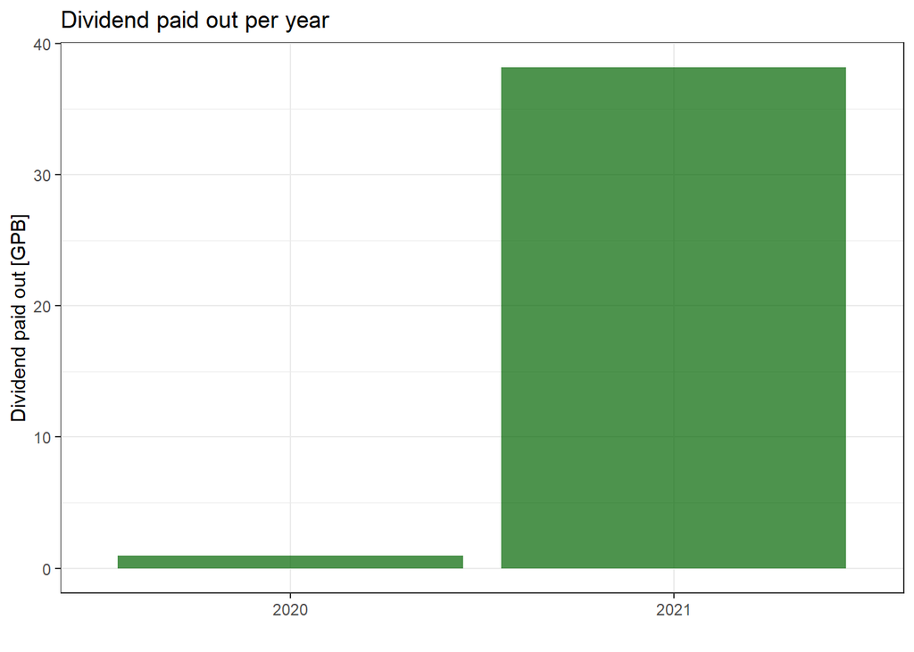

Figure 13.

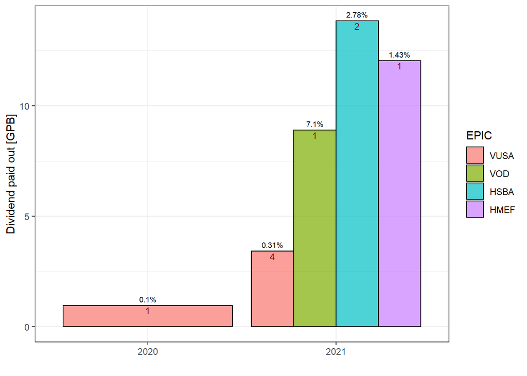

Figure 14.

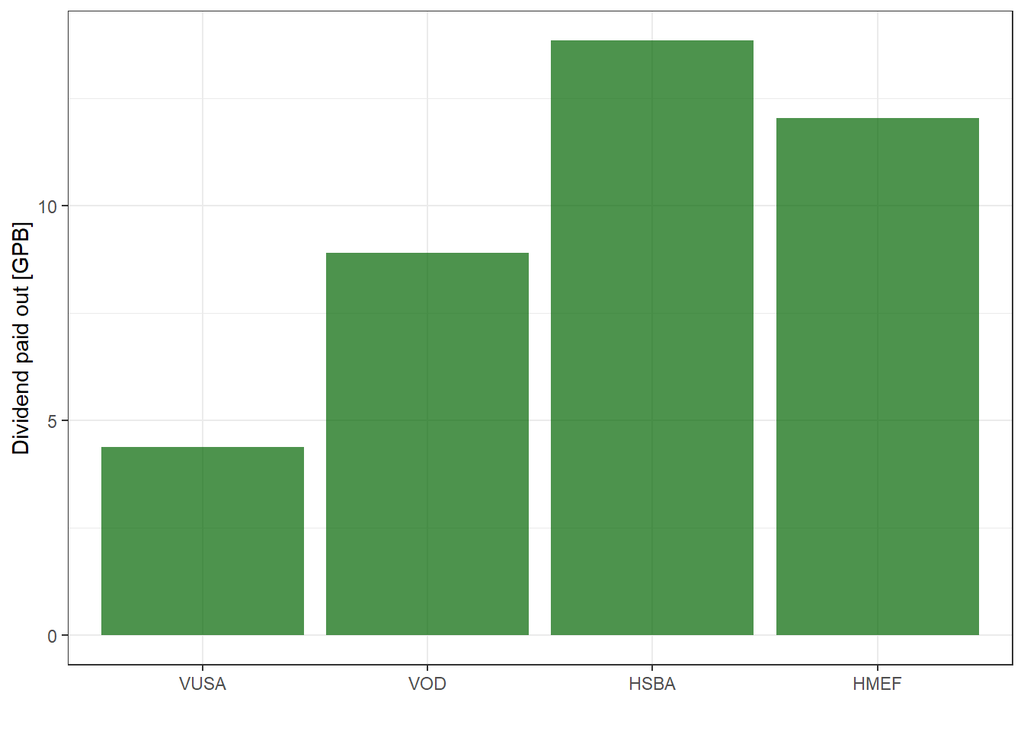

Figure 15.

## Dividends vs Trading costs

[output not shown]